# 실전 전처리 연습!

R로 배우는 데이터 분석 - 동화고

2022/08/10

# Exploring Data Frame

> 이번 챕터는 다른 패키지를 이용하지 않고 기본 R 코드만 이용하여 전처리하는 과정을 배워보겠습니다. 사용할 데이터셋은 Gapminder이며 웹사이트 Gapminder.org에서 다운로드 할 수 있습니다.

Gapminder 데이터셋은 142개국의 1952년부터 2007년 까지 5년 주기로 **기대수명**, **일인당 국민소득**, **인구수** 를 측정합니다..

### 데이터셋 받아오기 (Import Dataset)

```r
# load dataset
gap <- read.csv("gapminder.csv", stringsAsFactors = F)
```

### 데이터 차원 및 형태 확인하기 (Structure and Dimensions)

```r
# get number of rows and columns:
dim(gap)
```

```
## [1] 1704    6
```

```r
# see column names
names(gap)
```

```
## [1] "country"   "year"      "pop"       "continent" "lifeExp"   "gdpPercap"
```

```r
# see structure of data
str(gap)
```

```
## 'data.frame':    1704 obs. of  6 variables:
##  $ country  : chr  "Afghanistan" "Afghanistan" "Afghanistan" "Afghanistan" ...
##  $ year     : int  1952 1957 1962 1967 1972 1977 1982 1987 1992 1997 ...
##  $ pop      : num  8425333 9240934 10267083 11537966 13079460 ...
##  $ continent: chr  "Asia" "Asia" "Asia" "Asia" ...
##  $ lifeExp  : num  28.8 30.3 32 34 36.1 ...
##  $ gdpPercap: num  779 821 853 836 740 ...
```

```r
head(gap)
```

```
##       country year      pop continent lifeExp gdpPercap
## 1 Afghanistan 1952  8425333      Asia  28.801  779.4453
## 2 Afghanistan 1957  9240934      Asia  30.332  820.8530
## 3 Afghanistan 1962 10267083      Asia  31.997  853.1007
## 4 Afghanistan 1967 11537966      Asia  34.020  836.1971
## 5 Afghanistan 1972 13079460      Asia  36.088  739.9811
## 6 Afghanistan 1977 14880372      Asia  38.438  786.1134
```

### 데이터 변경 (Common Alterations)

1. 변수 이름 바꾸기 (Change column names)

```r
names(gap)
```

```
## [1] "country"   "year"      "pop"       "continent" "lifeExp"   "gdpPercap"
```

```r
names(gap) <- c("country", "year", "pop", "continent", "life.exp", "gdp.percap")
str(gap)
```

```
## 'data.frame':    1704 obs. of  6 variables:
##  $ country   : chr  "Afghanistan" "Afghanistan" "Afghanistan" "Afghanistan" ...
##  $ year      : int  1952 1957 1962 1967 1972 1977 1982 1987 1992 1997 ...
##  $ pop       : num  8425333 9240934 10267083 11537966 13079460 ...
##  $ continent : chr  "Asia" "Asia" "Asia" "Asia" ...
##  $ life.exp  : num  28.8 30.3 32 34 36.1 ...
##  $ gdp.percap: num  779 821 853 836 740 ...
```

2. 값 변경 (Change some values to `NA`)

```r
gap$life.exp[gap$life.exp < 0 ] <- NA
```

### 통계적 분포 확인 (Summary statistics)

`summary` 명령어를 이용하면 데이터셋의 각 열(column)에 대한 기본적인 통계적 분포를 확인할 수 있다. 직접 확인해보자.

```r
summary(gap)
```

```
##    country               year           pop             continent
##  Length:1704        Min.   :1952   Min.   :6.001e+04   Length:1704
##  Class :character   1st Qu.:1966   1st Qu.:2.794e+06   Class :character
##  Mode  :character   Median :1980   Median :7.024e+06   Mode  :character
##                     Mean   :1980   Mean   :2.960e+07
##                     3rd Qu.:1993   3rd Qu.:1.959e+07
##                     Max.   :2007   Max.   :1.319e+09
##     life.exp       gdp.percap
##  Min.   :23.60   Min.   :   241.2
##  1st Qu.:48.20   1st Qu.:  1202.1
##  Median :60.71   Median :  3531.8
##  Mean   :59.47   Mean   :  7215.3
##  3rd Qu.:70.85   3rd Qu.:  9325.5
##  Max.   :82.60   Max.   :113523.1
```

### Table

물론 기초통계를 확인하기 전에 우리는 항상 데이터의 관측 수 혹은 관측되는 형태를 먼저 간단하게 확인할 필요성이 있다. 이를 `table()` 명령어를 이용해서 확인해보자.

대륙 별 observation, 그리고 대륙과 연도별 observation을 확인해보자

```r
table(gap$continent)
```

```
##
##   Africa Americas     Asia   Europe  Oceania
##      624      300      396      360       24
```

```r
table(gap$continent, gap$year)
```

```
##
##            1952 1957 1962 1967 1972 1977 1982 1987 1992 1997 2002 2007
##   Africa     52   52   52   52   52   52   52   52   52   52   52   52
##   Americas   25   25   25   25   25   25   25   25   25   25   25   25
##   Asia       33   33   33   33   33   33   33   33   33   33   33   33
##   Europe     30   30   30   30   30   30   30   30   30   30   30   30
##   Oceania     2    2    2    2    2    2    2    2    2    2    2    2
```

table을 활용할 때 관측수를 분포도 혹은 백분위로 변경하여 확인할 수 있다.

```r
table(gap$continent)/nrow(gap)
```

```
##
##     Africa   Americas       Asia     Europe    Oceania
## 0.36619718 0.17605634 0.23239437 0.21126761 0.01408451
```

```r
table(gap$continent)/nrow(gap)*100
```

```
##
##    Africa  Americas      Asia    Europe   Oceania
## 36.619718 17.605634 23.239437 21.126761  1.408451
```

### 데이터 추출 (Review of Subsetting)

바로 전에 배웠던 Subsetting을 활용해보자.

```r
# Extract first 10 rows
# Extract county year for first 10 rows
# Extract observations in Africa
# Find average life expectancy for observations in Africa
```

### Basic Plotting

일인당 GDP와 기대수명과의 상관관계

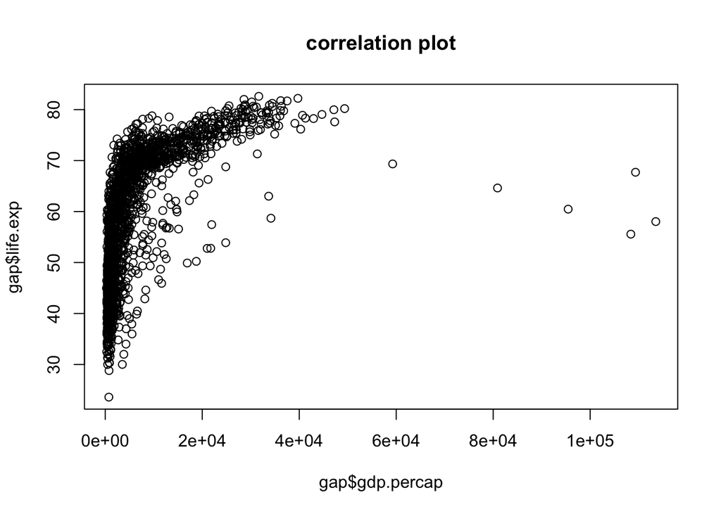

```r
plot(gap$life.exp ~ gap$gdp.percap, main="correlation plot")
```

기대수명 빈도분포표 (frequency histogram)

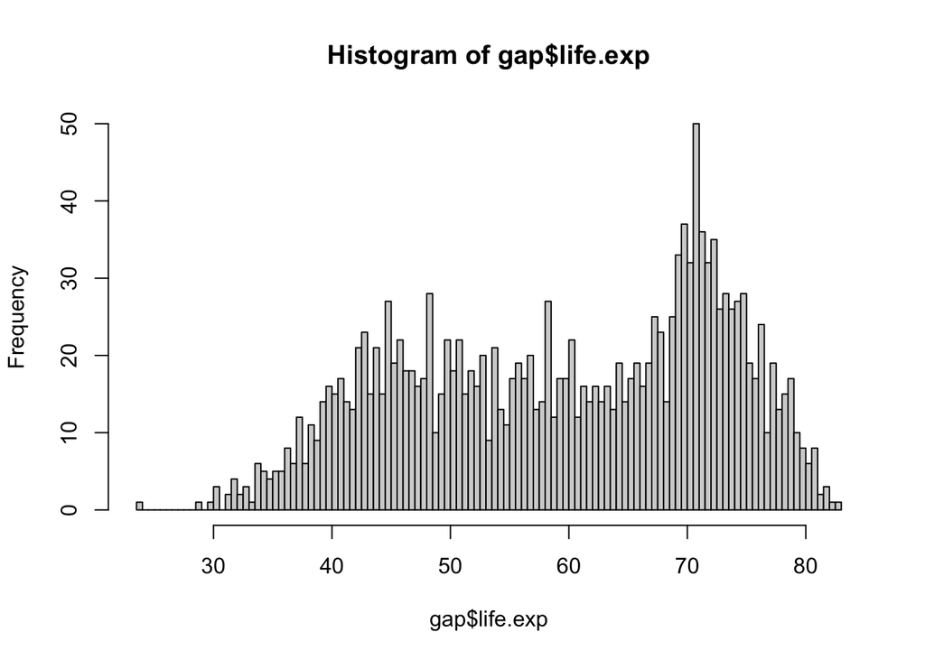

```r
hist(gap$life.exp, breaks = 100)
```